# Resonance Tank Capacitor and Output Capacitor

- Resonance Tank Capacitor and Output Capacitor
  - Inputs and claculated parameters
  - Output capacitor Co
    - Formulas
    - Numerical Implementation of the Formulas
    - First proposition
    - Second proposition
    - Comparaison
  - Resonanat capacitor Cr
    - Chosing a capacitor for Cr
    - Understanding the Derating Curve of the Capacitors
    - Resonant capacitors configuration
  - References

## Inputs and claculated parameters

```
V_In_min 360.0 V_In_max 400.0 Vo_nom 48.0 Power   1200.0
V_In_nom 380.0   Vo_min  42.0 Vo_max 54.0 f_nom 100000.0


  Lnc   3.000   Lm_uH     65.392     Ioe_rms  7.636 Re_110    22.637
  Qec   0.550 fsw_min  60170.000     Ios_rms 30.545     Cr       0.0
Cr_nF 116.209 fsw_max 156220.000      Ir_rms 10.354     Lr  0.000022
    n   4.000  Im_rms      6.992 L_second_uH  4.087     Lm  0.000065
Lr_uH  21.797      Io     25.000      Re_nom 24.901
```

## Output capacitor Co

### Basic sizing (capacitive ripple only)

$C_o \ge C_{o_{min}}$

$C_{o_{min}} = \dfrac{I_o}{8\,f_{sw}\,\Delta V_{outC}}$

$\Delta V_{outC} = \dfrac{I_o}{8\,f_{sw}\,C_o}$

Where:

- $C_o$ : Output capacitance (Farads, F)
- $I_o$ : Output load current (Amperes, A)
- $f_{sw}$ : Switching frequency of the converter (Hertz, Hz)
- $\Delta V_{out}$ : Maximum allowed output voltage ripple (Volts, V)
- $ESR$ : Equivalent Series Resistance of the capacitor (Ω)

### ESR-related terms

$ESR_{max} = \dfrac{\Delta V_{outR}}{I_{rect\_peak}}$

$\Delta V_{outR} = I_{rect\_peak}\cdot ESR$

Where $I_{rect\_peak} = \dfrac{\pi}{2}\,I_o$

So:  
$\Delta V_{outR} = \dfrac{\pi}{2}\,I_o\cdot ESR$

### Capacitor RMS current

$I_{C_o} = I_o \sqrt{\dfrac{\pi^2}{8} - 1}$

### Total ripple — vector (RMS) sum with 90° phase shift

$\Delta V_{out} = \sqrt{\Delta V_{outC}^2 + \Delta V_{outR}^2}$

$\Delta V_{out} = \sqrt{\left(\dfrac{I_o}{8\,f_{sw}\,C_o}\right)^2 + \left(I_{rect\_peak}\cdot ESR\right)^2}$

Replace $I_{rect\_peak}$:  
$\Delta V_{out} = \sqrt{\left(\dfrac{I_o}{8\,f_{sw}\,C_o}\right)^2 + \left(\dfrac{\pi}{2}\,I_o\cdot ESR\right)^2}$

### Solve for $C_o$ (RMS sum)

$C_o \ge \dfrac{I_o}{8\,f_{sw}\,\sqrt{\Delta V_{out}^2 - \left(\dfrac{\pi}{2}\,I_o\cdot ESR\right)^2}}$  
Condition: $\Delta V_{out} > \dfrac{\pi}{2}\,I_o\cdot ESR$

### Solve for $ESR$ (RMS sum)

$ESR \le \dfrac{1}{\dfrac{\pi}{2}\,I_o} \sqrt{\Delta V_{out}^2 - \left(\dfrac{I_o}{8\,f_{sw}\,C_o}\right)^2}$

### Optional split of ripple budget (50%-50% rule)

$\Delta V_{outR} < \dfrac{\Delta V_{out,max}}{2}$

$\Delta V_{outC} < \dfrac{\Delta V_{out,max}}{2}$

**Implied bounds with 50/50 split:**

$C_o \ge \dfrac{I_o}{8\,f_{sw}\,\left(\dfrac{\Delta V_{out,max}}{2}\right)} = \dfrac{I_o}{4\,f_{sw}\,\Delta V_{out,max}}$

$ESR \le \dfrac{\dfrac{\Delta V_{out,max}}{2}}{\dfrac{\pi}{2}\,I_o} = \dfrac{\Delta V_{out,max}}{\pi\,I_o}$

### Numerical Implementation of the Formulas 50% 50%

**We must use fsw_min to the worst case**

$ \begin{aligned} \mathrm{Io} &= 25.000 \; \;\textrm{(A)} \\[10pt] \mathrm{fsw}_{min} &= 60170.000 \; \;\textrm{(Hz)} \\[10pt] \mathrm{DV} &= 0.250 \; \;\textrm{(vpp)} \\[10pt] \mathrm{Co}_{min_{uF}} &= 1 \times 10 ^ {6} \cdot \frac{ \mathrm{Io} }{ 4 \cdot \mathrm{fsw}_{min} \cdot \mathrm{DV} } \\&= 1 \times 10 ^ {6} \cdot \frac{ 25.000 }{ 4 \cdot 60170.000 \cdot 0.250 } \\&= 415.489 \; \;\textrm{(uF)}\\[10pt] \end{aligned} $

$ \begin{aligned} \mathrm{ESR}_{max_{m}} &= 1 \times 10 ^ {3} \cdot \frac{ \mathrm{DV} }{ \mathrm{Io} \cdot \pi } \\&= 1 \times 10 ^ {3} \cdot \frac{ 0.250 }{ 25.000 \cdot 3.142 } \\&= 3.183 \; \;\textrm{(mΩ)}\\[10pt] \\[10pt] I_{Co} &= \mathrm{Io} \cdot \sqrt { \frac{ \left( \pi \right) ^{ 2 } }{ 8 } - 1 } \\&= 25.000 \cdot \sqrt { \frac{ \left( 3.142 \right) ^{ 2 } }{ 8 } - 1 } \\&= 12.086 \; \;\textrm{(Arms)}\\[10pt] \end{aligned} $

### First proposition

B40910A8127M000 aluminum electrolytic capacitors with Temp_max = 150°C, Below a screenshoot of the datasheet [2].

[figure not shown]

**Figure 1:** B40910A8127M000 aluminum electrolytic capacitors with Temp_max = 150°C

Let's start with a configuration of 6 capacitors in parallel, in the worst case ($C_{capa}= C_{min}$ of the datasheet)

$ \begin{aligned} \mathrm{Nb}_{capa} &= 6 \; \\[10pt] C_{capa_{nom}} &= 120 \; \;\textrm{(uF)} \\[10pt] \mathrm{Margin} &= 20 \; \;\textrm{(\%)} \\[10pt] C_{capa} &= C_{capa_{nom}} \cdot \left( 1 - \frac{ \mathrm{Margin} }{ 100 } \right) = 120 \cdot \left( 1 - \frac{ 20 }{ 100 } \right) &= 96.000 \; \;\textrm{(uF, Worst case)} \end{aligned} $

$ \begin{aligned} C_{eq} &= C_{capa} \cdot \mathrm{Nb}_{capa} = 96.000 \cdot 6 &= 576.000 \; \;\textrm{(uF > 415uF ok)} \\[10pt] \mathrm{ESR}_{capa} &= 17 \; \;\textrm{(Ω @ 100kHz)} \\[10pt] \mathrm{ESR}_{eq} &= \frac{ \mathrm{ESR}_{capa} }{ \mathrm{Nb}_{capa} } = \frac{ 17 }{ 6 } &= 2.833 \; \;\textrm{(Ω < 3.18m OK)} \\[10pt] \mathrm{Icapa}_{max} &= 4.600 \; \end{aligned} $

$ \begin{aligned} \mathrm{Ieq}_{max} &= \mathrm{Icapa}_{max} \cdot \mathrm{Nb}_{capa} \\&= 4.600 \cdot 6 \\&= 27.600 \; \;\textrm{(@ Arms @ 125°C 100kHz > 12.08Arms ok)}\\[10pt] \end{aligned} $

**I_rect_peak**

$ \begin{aligned} I_{rect_{peak}} &= \mathrm{Io} \cdot \frac{ \pi }{ 2 } = 25.000 \cdot \frac{ 3.142 }{ 2 } &= 39.270 \; \;\textrm{(A)} \end{aligned} $

**Voltage ripples**

$ \begin{aligned} \Delta_{V_{out}} &= \sqrt { \left( \frac{ \mathrm{Io} }{ 8 \cdot \mathrm{fsw}_{min} \cdot C_{eq} \cdot 1 \times 10 ^ {-6} } \right) ^{ 2 } + \left( \frac{ \pi }{ 2 } \cdot \mathrm{Io} \cdot \mathrm{ESR}_{eq} \cdot 1 \times 10 ^ {-3} \right) ^{ 2 } } \\&= \sqrt { \left( \frac{ 25.000 }{ 8 \cdot 60170.000 \cdot 576.000 \cdot 1 \times 10 ^ {-6} } \right) ^{ 2 } + \left( \frac{ 3.142 }{ 2 } \cdot 25.000 \cdot 2.833 \cdot 1 \times 10 ^ {-3} \right) ^{ 2 } } \\&= 0.143 \; \;\textrm{(V < 0.25V Ok)}\\[10pt] \end{aligned} $

#### Self heating

**Power Dissipation of Each Capacitor**

$ \begin{aligned} I_{each_{capa}} &= \frac{ I_{Co} }{ \mathrm{Nb}_{capa} } \\&= \frac{ 12.086 }{ 6 } \\&= 2.014 \; \;\textrm{(A)}\\[10pt] \\[10pt] P_{selfHeating} &= \mathrm{ESR}_{capa} \cdot 1 \times 10 ^ {-3} \cdot \left( I_{each_{capa}} \right) ^{ 2 } \\&= 17 \cdot 1 \times 10 ^ {-3} \cdot \left( 2.014 \right) ^{ 2 } \\&= 0.069 \; \;\textrm{(W)}\\[10pt] \end{aligned} $

**Estimation of Thermal Resistance Rth**

$ \begin{aligned} \Delta_{T} &= 150 - 125 &= 25 \; \;\textrm{(°C)} \\[10pt] \mathrm{ESR} &= 0.017 \; \\[10pt] I &= 4.600 \; \;\textrm{(Arms)} \\[10pt] P_{dissip} &= \mathrm{ESR} \cdot \left( I \right) ^{ 2 } \\&= 0.017 \cdot \left( 4.600 \right) ^{ 2 } \\&= 0.360 \; \;\textrm{(W)}\\[10pt] \\[10pt] R_{th} &= \frac{ \Delta_{T} }{ P_{dissip} } \\&= \frac{ 25 }{ 0.360 } \\&= 69.498 \; \;\textrm{(°C/W)}\\[10pt] \end{aligned} $

**The self heating estimation and the max ambiant temp**

$ \begin{aligned} \Delta_{T} &= P_{selfHeating} \cdot R_{th} \\&= 0.069 \cdot 69.498 \\&= 4.794 \; \;\textrm{(°C => low delta temp)}\\[10pt] \\[10pt] \mathrm{Margin} &= 30 \; \;\textrm{(°C)} \\[10pt] T_{max} &= 150 \; \\[10pt] T_{amb_{max}} &= T_{max} - \Delta_{T} - \mathrm{Margin} \\&= 150 - 4.794 - 30 \\&= 115.206 \; \;\textrm{(°C)}\\[10pt] \end{aligned} $

**Voltage margin**

$ \begin{aligned} \mathrm{Vo}_{max} &= 54.000 \; \;\textrm{(VDC)} \\[10pt] V_{max_{datasheet}} &= 63 \; \;\textrm{(VDC)} \\[10pt] \mathrm{Voltage}_{Margin} &= 100 \cdot \frac{ V_{max_{datasheet}} - \mathrm{Vo}_{max} }{ V_{max_{datasheet}} } \\&= 100 \cdot \frac{ 63 - 54.000 }{ 63 } \\&= 14.286 \; \;\textrm{(\%)}\\[10pt] \end{aligned} $

This solution is acceptable, but the voltage margin is limited.

### Second proposition

EMHS101ARA331MMN0S aluminum electrolytic capacitors with Temp_max = 150°C, Below a screenshoot of the datasheet [4].

[figure not shown]

**Figure 2:** EMHS101ARA331MMN0S aluminum electrolytic capacitors with Temp_max = 150°C

Let's start with a configuration of 10 capacitors in parallel, in the worst case ($C_{capa}= C_{min}$ of the datasheet)

$ \begin{aligned} \mathrm{Nb}_{capa} &= 10 \; \\[10pt] C_{capa_{nom}} &= 330 \; \;\textrm{(uF)} \\[10pt] \mathrm{Margin} &= 20 \; \;\textrm{(\%)} \\[10pt] C_{capa} &= C_{capa_{nom}} \cdot \left( 1 - \frac{ \mathrm{Margin} }{ 100 } \right) = 330 \cdot \left( 1 - \frac{ 20 }{ 100 } \right) &= 264.000 \; \;\textrm{(uF, Worst case)} \end{aligned} $

$ \begin{aligned} C_{eq} &= C_{capa} \cdot \mathrm{Nb}_{capa} = 264.000 \cdot 10 &= 2640.000 \; \;\textrm{(uF > 415uF ok)} \\[10pt] \mathrm{ESR}_{capa} &= 59 \; \;\textrm{(Ω @ 100kHz)} \\[10pt] \mathrm{ESR}_{eq} &= \frac{ \mathrm{ESR}_{capa} }{ \mathrm{Nb}_{capa} } = \frac{ 59 }{ 10 } &= 5.900 \; \;\textrm{(Ω > 3.18m NOK)} \end{aligned} $

Since the ESR does not satisfy the 50%–50% condition of the formula, we must use the full (unsimplified) expression for the voltage ripple.

$ \begin{aligned} \mathrm{Icapa}_{max} &= 2.300 \; \end{aligned} $

$ \begin{aligned} \mathrm{Ieq}_{max} &= \mathrm{Icapa}_{max} \cdot \mathrm{Nb}_{capa} \\&= 2.300 \cdot 10 \\&= 23.000 \; \;\textrm{(@ Arms @ 125°C 100kHz > 12.08Arms ok)}\\[10pt] \end{aligned} $

**I_rect_peak**

$ \begin{aligned} I_{rect_{peak}} &= \mathrm{Io} \cdot \frac{ \pi }{ 2 } = 25.000 \cdot \frac{ 3.142 }{ 2 } &= 39.270 \; \;\textrm{(A)} \end{aligned} $

**Voltage ripples**

$ \begin{aligned} \Delta_{V_{out}} &= \sqrt { \left( \frac{ \mathrm{Io} }{ 8 \cdot \mathrm{fsw}_{min} \cdot C_{eq} \cdot 1 \times 10 ^ {-6} } \right) ^{ 2 } + \left( \frac{ \pi }{ 2 } \cdot \mathrm{Io} \cdot \mathrm{ESR}_{eq} \cdot 1 \times 10 ^ {-3} \right) ^{ 2 } } \\&= \sqrt { \left( \frac{ 25.000 }{ 8 \cdot 60170.000 \cdot 2640.000 \cdot 1 \times 10 ^ {-6} } \right) ^{ 2 } + \left( \frac{ 3.142 }{ 2 } \cdot 25.000 \cdot 5.900 \cdot 1 \times 10 ^ {-3} \right) ^{ 2 } } \\&= 0.233 \; \;\textrm{(V < 0.25V Ok)}\\[10pt] \end{aligned} $

The condition is satisfied, but with a very limited margin.

#### Self heating

**Power Dissipation of Each Capacitor**

$ \begin{aligned} I_{each_{capa}} &= \frac{ I_{Co} }{ \mathrm{Nb}_{capa} } = \frac{ 12.086 }{ 10 } &= 1.209 \\[10pt] P_{selfHeating} &= \mathrm{ESR}_{capa} \cdot 1 \times 10 ^ {-3} \cdot \left( I_{each_{capa}} \right) ^{ 2 } \\&= 59 \cdot 1 \times 10 ^ {-3} \cdot \left( 1.209 \right) ^{ 2 } \\&= 0.086 \; \;\textrm{(W)}\\[10pt] \end{aligned} $

**Estimation of Thermal Resistance Rth**

$ \begin{aligned} \Delta_{T} &= 150 - 125 &= 25 \; \;\textrm{(°C)} \\[10pt] P_{dissip} &= \mathrm{ESR}_{capa} \cdot 1 \times 10 ^ {-3} \cdot \left( \mathrm{Icapa}_{max} \right) ^{ 2 } \\&= 59 \cdot 1 \times 10 ^ {-3} \cdot \left( 2.300 \right) ^{ 2 } \\&= 0.312 \; \;\textrm{(W)}\\[10pt] \\[10pt] R_{th} &= \frac{ \Delta_{T} }{ P_{dissip} } = \frac{ 25 }{ 0.312 } &= 80.100 \; \;\textrm{(°C/W)} \end{aligned} $

**The self heating estimation and the max ambiant temp**

$ \begin{aligned} \Delta_{T} &= P_{selfHeating} \cdot R_{th} = 0.086 \cdot 80.100 &= 6.903 \; \;\textrm{(°C => low delta temp)} \\[10pt] \mathrm{Margin} &= 30 \; \;\textrm{(°C)} \\[10pt] T_{max} &= 150 \; \\[10pt] T_{amb_{max}} &= T_{max} - \Delta_{T} - \mathrm{Margin} = 150 - 6.903 - 30 &= 113.097 \; \;\textrm{(°C)} \end{aligned} $

$ \begin{aligned} \mathrm{Vo}_{max} &= 54.000 \; \;\textrm{(VDC)} \\[10pt] V_{max_{datasheet}} &= 100 \; \;\textrm{(VDC)} \\[10pt] \mathrm{Voltage}_{Margin} &= 100 \cdot \frac{ V_{max_{datasheet}} - \mathrm{Vo}_{max} }{ V_{max_{datasheet}} } = 100 \cdot \frac{ 100 - 54.000 }{ 100 } &= 46.000 \; \;\textrm{(\%)} \end{aligned} $

### Comparaison

|  | requirements | Solutio1 | Solutio2 |
| --- | --- | --- | --- |
| ESR_eq | 3.18 | 2.83 | 5.90 |
| C_eq | 415.49 | 576.00 | 2640.00 |
| Ieq_max | 12.09 | 27.60 | 23.00 |
| VmaxDC | 54.00 | 63.00 | 100.00 |
| Delta_V_out | 0.25 | 0.14 | 0.23 |
| C_capa | NaN | 96.00 | 264.00 |
| Nb_capa | NaN | 6.00 | 10.00 |
| P_selfHeating | NaN | 0.07 | 0.09 |
| T_amb_max | NaN | 115.21 | 113.10 |
| Voltage_Margin | NaN | 14.29 | 46.00 |

*) The ESR requirement is based on the 50%–50% formula (see above for solution2).

## Resonanat capacitor Cr

### Chosing a capacitor for Cr

**The inputs data**

$ \begin{aligned} \mathrm{Cr}_{nF} &= 116.209 \; \;\textrm{(nF)} \\[10pt] V_{In_{max}} &= 400.000 \; \;\textrm{(V)} \\[10pt] \mathrm{fsw}_{min} &= 60170.000 \; \;\textrm{(Hz)} \end{aligned} $

**The RMS voltage of the resonant capacitor**

$ \begin{aligned} X_{Cr} &= \frac{ 1 }{ 2 \cdot \pi \cdot \mathrm{fsw}_{min} \cdot \mathrm{Cr}_{nF} \cdot 1 \times 10 ^ {-9} } \\&= \frac{ 1 }{ 2 \cdot 3.142 \cdot 60170.000 \cdot 116.209 \cdot 1 \times 10 ^ {-9} } \\&= 22.761 \; \;\textrm{(Ohm)}\\[10pt] \end{aligned} $

$ \begin{aligned} V_{Cr} &= \mathrm{Ir}_{rms} \cdot X_{Cr} = 10.354 \cdot 22.761 &= 235.672 \; \;\textrm{(V)} \\[10pt] V_{Cr_{rms}} &= \sqrt { \left( \frac{ V_{In_{max}} }{ 2 } \right) ^{ 2 } + \left( V_{Cr} \right) ^{ 2 } } = \sqrt { \left( \frac{ 400.000 }{ 2 } \right) ^{ 2 } + \left( 235.672 \right) ^{ 2 } } &= 309.098 \; \;\textrm{(vrms)} \end{aligned} $

```
The design value of Cr is 116.2 nF
Below are some possible combinations for constructing this resonant capacitor:
```

|  | Nominal_capa_nF | Nb capas in parallel | total capa nF | error % |
| --- | --- | --- | --- | --- |
| 0 | 6.2 | 19 | 117.8 | 1.4 |
| 1 | 6.8 | 17 | 115.6 | -0.5 |
| 2 | 8.2 | 14 | 114.8 | -1.2 |
| 3 | 10.0 | 12 | 120.0 | 3.3 |
| 4 | 12.0 | 10 | 120.0 | 3.3 |
| 5 | 15.0 | 8 | 120.0 | 3.3 |
| 6 | 22.0 | 5 | 110.0 | -5.3 |
| 7 | 33.0 | 4 | 132.0 | 13.6 |
| 8 | 47.0 | 2 | 94.0 | -19.1 |
| 9 | 56.0 | 2 | 112.0 | -3.6 |
| 10 | 68.0 | 2 | 136.0 | 17.0 |

**The current of each element capacitor**

$ \begin{aligned} \mathrm{Ir}_{rms_{1}} &= 1.294 \; \end{aligned} $

**The 15 nF, 15 mm, 2000 VDC TDK MKP capacitor meets both the Vrms and Irms requirements.**

[figure not shown]

**Figure 3:** Vrms 15 nF, 15 mm, 2000 VDC TDK MKP

[figure not shown]

**Figure 4:** Irms 15 nF, 15 mm, 2000 VDC TDK MKP

Below is a screenshot from the B32672L datasheet. The ref **B32672L8153** is a 15 nF capacitor.

[figure not shown]

**Figure 5:** B32672L8153 is a 15 nF capacitor.

**The ESR and Power dissipation**

[figure not shown]

**Figure 6:** ESR and Thermal derating

From the below  
6.8nF ESR=70µΩ  
33nF ESR=50µΩ  
By linear interpolation, the ESR of a 15 nF capacitor can be estimated as 63.74 µΩ

**The power dissipation of each capacitor**

$ \begin{aligned} \mathrm{ESR}_{u} &= 63.740 \; \;\textrm{(µΩ)} \\[10pt] \mathrm{Ir}_{rms_{1}} &= 1.294 \; \;\textrm{(Arms)} \\[10pt] \mathrm{Ir}_{rms_{max}} &= 2 \; \;\textrm{(Arms)} \\[10pt] \mathrm{PD}_{uW} &= \mathrm{ESR}_{u} \cdot \left( \mathrm{Ir}_{rms_{1}} \right) ^{ 2 } = 63.740 \cdot \left( 1.294 \right) ^{ 2 } &= 106.771 \; \;\textrm{(uW)} \end{aligned} $

**The Rth estimation**

$ \begin{aligned} T_{max} &= 125 \; \\[10pt] T_{100} &= 100 \; \\[10pt] \Delta_{T} &= T_{max} - T_{100} = 125 - 100 &= 25 \\[10pt] \mathrm{PD}_{uW_{max}} &= \mathrm{ESR}_{u} \cdot \left( \mathrm{Ir}_{rms_{max}} \right) ^{ 2 } = 63.740 \cdot \left( 2 \right) ^{ 2 } &= 254.962 \\[10pt] R_{TH} &= \frac{ \Delta_{T} }{ \mathrm{PD}_{uW_{max}} } = \frac{ 25 }{ 254.962 } &= 0.098 \; \;\textrm{(°C/uW)} \end{aligned} $

**Each capacitor's self-heating and the maximum permissible ambient temperature.**

$ \begin{aligned} \Delta_{T} &= \mathrm{PD}_{uW} \cdot R_{TH} = 106.771 \cdot 0.098 &= 10.469 \; \;\textrm{(°C)} \\[10pt] T_{amb_{max}} &= 125 - \Delta_{T} = 125 - 10.469 &= 114.531 \; \;\textrm{(°C)} \end{aligned} $

### Understanding the Derating Curve of the Capacitors

**One point calculation**

$ \begin{aligned} \mathrm{Ta} &= 105 \; \\[10pt] \Delta_{T} &= T_{max} - \mathrm{Ta} = 125 - 105 &= 20 \\[10pt] \mathrm{PD}_{uW_{max}} &= \frac{ \Delta_{T} }{ R_{TH} } = \frac{ 20 }{ 0.098 } &= 203.969 \\[10pt] \mathrm{Ir}_{rms_{max_{Ta}}} &= 1.789 \; \\[10pt] \mathrm{Fa} &= \frac{ \mathrm{Ir}_{rms_{max_{Ta}}} }{ \mathrm{Ir}_{rms_{max}} } = \frac{ 1.789 }{ 2 } &= 0.894 \end{aligned} $

**The same calculation is repeated to construct the derating curve.**

```
(80.0, 125.0)
```

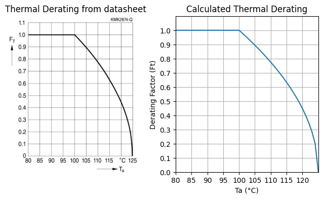

### Resonant capacitors configuration

There are two possible configurations for the resonant capacitors:

- All capacitors in parallel:

which is the classic LLC configuration and offers simplicity in layout.

- Dividing the capacitors between the high side and low side:

which helps balance HV+ and HV-.

Below is a simulation of both solutions. We can see that the voltage and current of each capacitor are almost identical in both configurations, and all other voltages and currents are also very similar.

You can donwload the LTSPICE file using this Link.

[figure not shown]

**Figure 7:** Simulation of resonant capacitor configurations

## References

[1] Hong Huang, *Designing an LLC Resonant Half-Bridge Power Converter*. Available: https://bbs.dianyuan.com/upload/community/2013/12/01/1385867010-65563.pdf

[2] [B40910 Aluminum electrolytic capacitors datasheet](https://product.tdk.com/system/files/dam/doc/product/capacitor/aluminum-electrolytic/hybrid-polymer/data_sheet/20/30/db/aec/b40910.pdf)

[3] [B3267*L Film Capacitors](https://product.tdk.com/system/files/dam/doc/product/capacitor/film/mkp_mfp/data_sheet/20/20/db/fc_2009/mkp_b32671l_672l.pdf)

[4] [EMHS Aluminum electrolytic capacitors datasheet](https://www.mouser.fr/datasheet/2/420/Chemi_Con_MHSRA_e-3313675.pdf)